# **- ATOC 568 -** **Modelling lab**

# Supporting material

## **Definition of the domain**

### **SIZE.h**

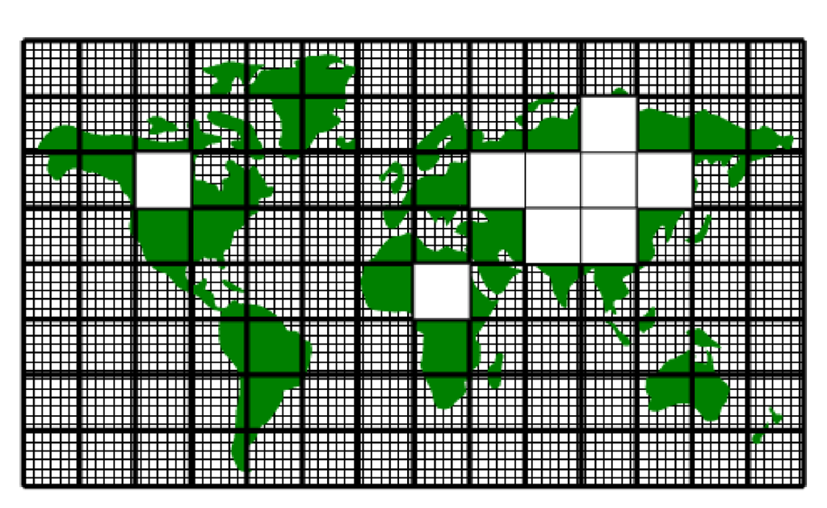

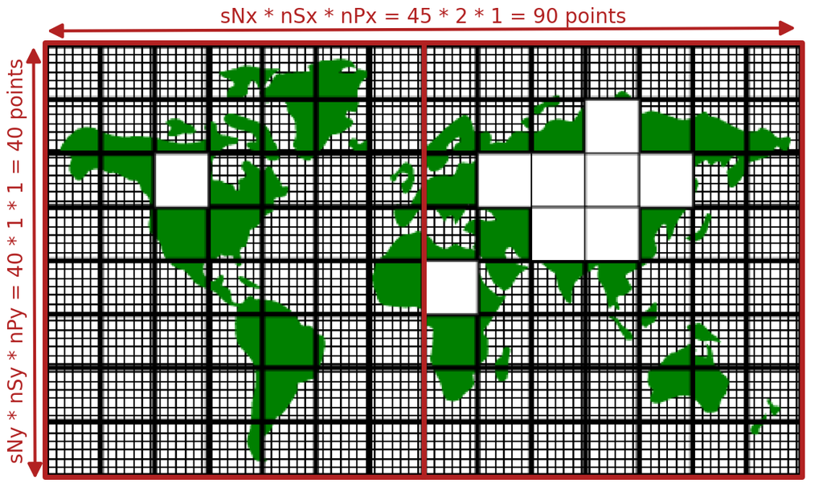

Source: https://mitgcm.readthedocs.io/en/latest/software_arch/software_arch.html#tile-layout

## **Redi/Gent and McWilliams parameterization**

### **`gmredi` package**

Redi/GM parameterization represents the effect of geostrophic eddies

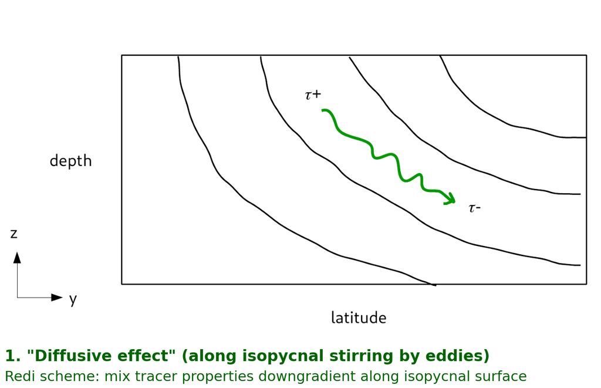

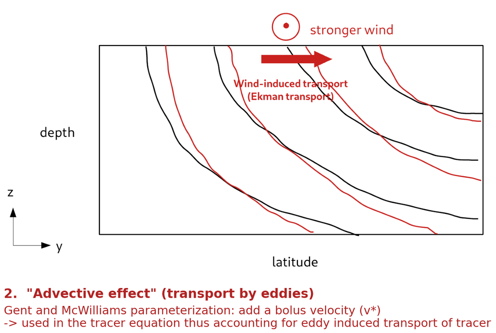

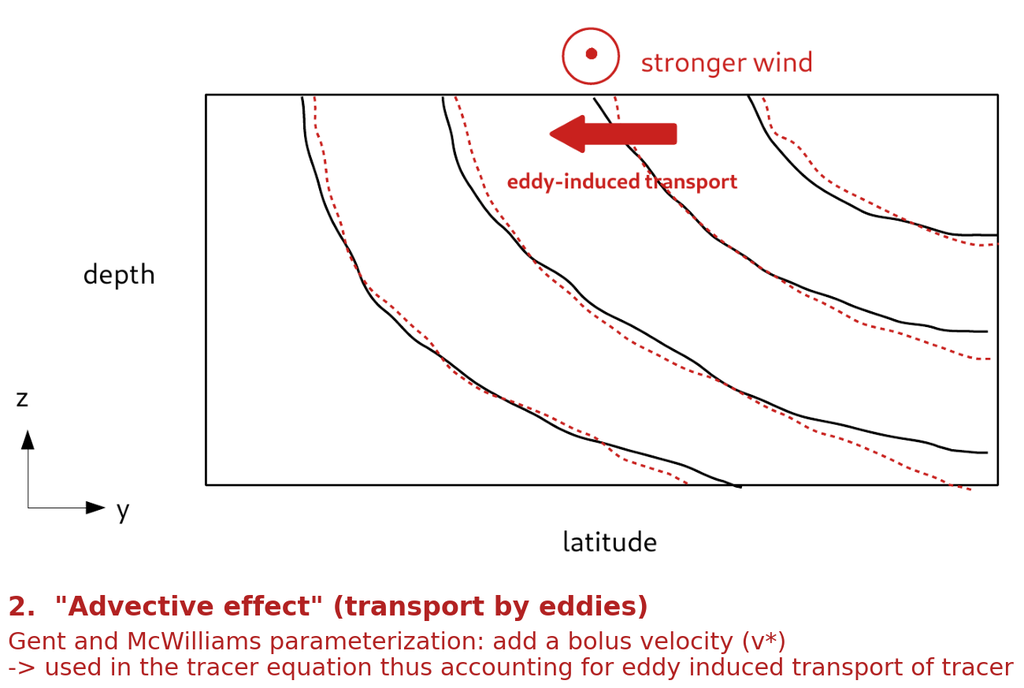

$\,$
$\,$
$$ u^{*}=\begin{pmatrix}u^{*}\\v^{*}\\w^{*}\end{pmatrix}=\begin{pmatrix}-\partial_{z}(\kappa_{GM}S_{x})\\-\partial_{z}(\kappa_{GM}S_{y})\\\partial_{x}(\kappa_{GM}S_{x})+\partial_{y}(\kappa_{GM}S_{y})\end{pmatrix} $$

$$ \kappa_{GM}: \mathrm{GM\,\,coeffcicient} $$$$ S_{x}=-\frac{\partial_{x}\sigma}{\partial_{z}\sigma} $$$$ S_{y}=-\frac{\partial_{y}\sigma}{\partial_{z}\sigma} $$

## **Experiments**

### **pickup**

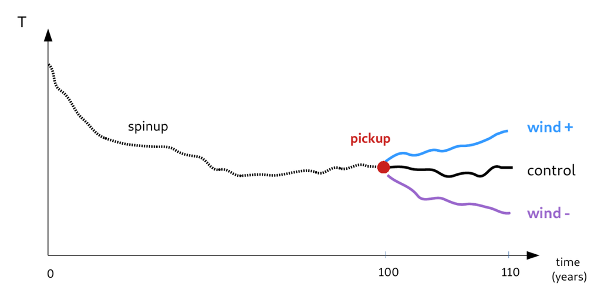

### **Sensitivity experiments**

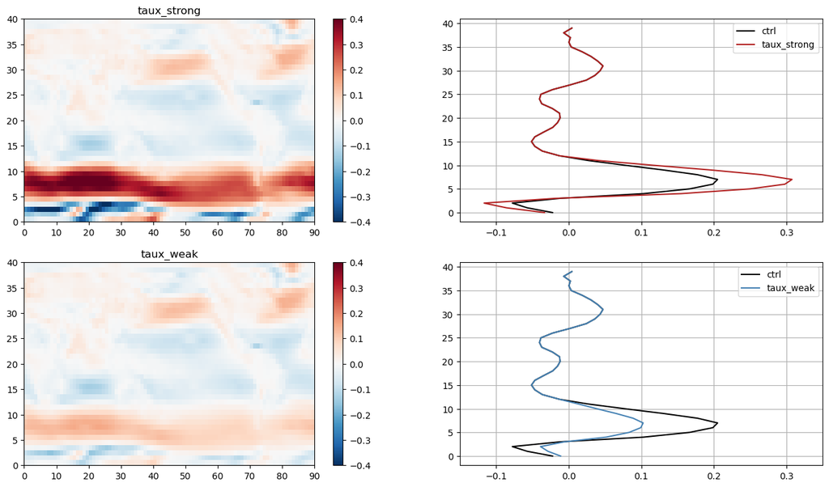

## **List of plots**

### **Methods section**

#### 1. Comparison of surface temperature, salinity, summer and winter mixed layer depths with observations (for each variable, plot the model field, the observational field and the model minus observation field)

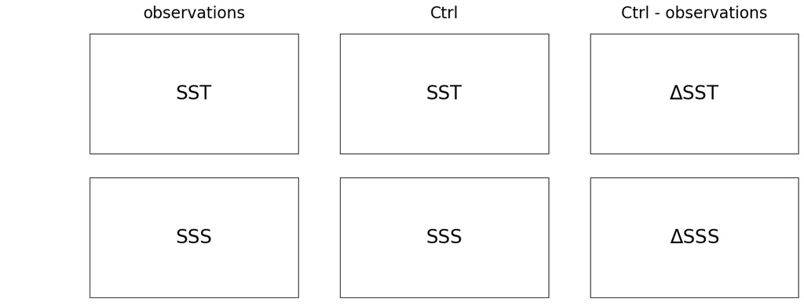

- Observations are the files used for initialization of the models (See **section II.1 of session #1**) `lev_t.bin` and `lev_s.bin`

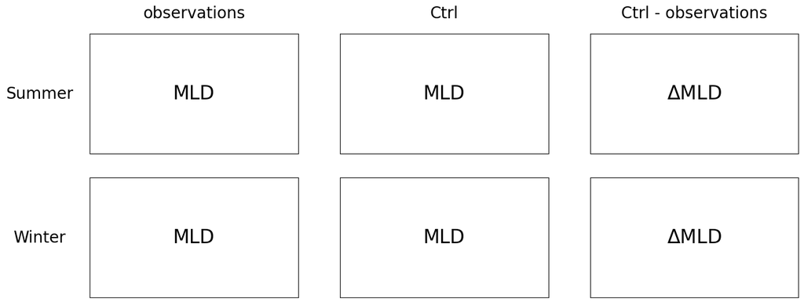

- Model: MLD found as an output called `MXLDEPTH` in `Sdiag_MLD.0000036000.t00x.nc`
- Observations: MLD needs to be calculated (see below)

#### 2. Timeseries of the control Antarctic Circumpolar Current (ACC) transport starting from year 0 of the spinup

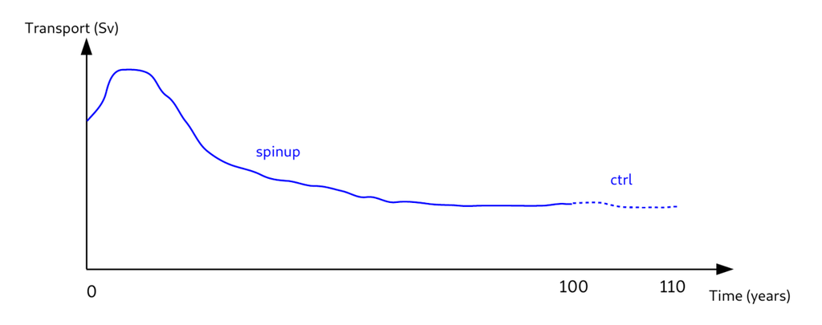

- Spinup: model output found in

`/home/shared/spinup/mnc0001/`

- Ctrl: model output from your ctrl simulation

#### 3. Plot of the control Meridional Overturning Circulation (MOC)

Residual MOC = Eulerian mean component + eddy component (Given by the GM parameterization)

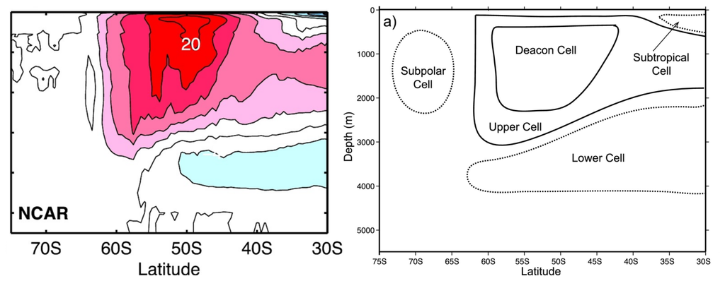

[Farneti et al. (2015)](https://www.sciencedirect.com/science/article/pii/S1463500315001183)

- Compute both components and add them to calculate the residual MOC
- Plot the residual MOC for the ctrl

### **Result section**

#### 1. Plot all components of the MOC (Eulerian, GM and residual) for each simulation

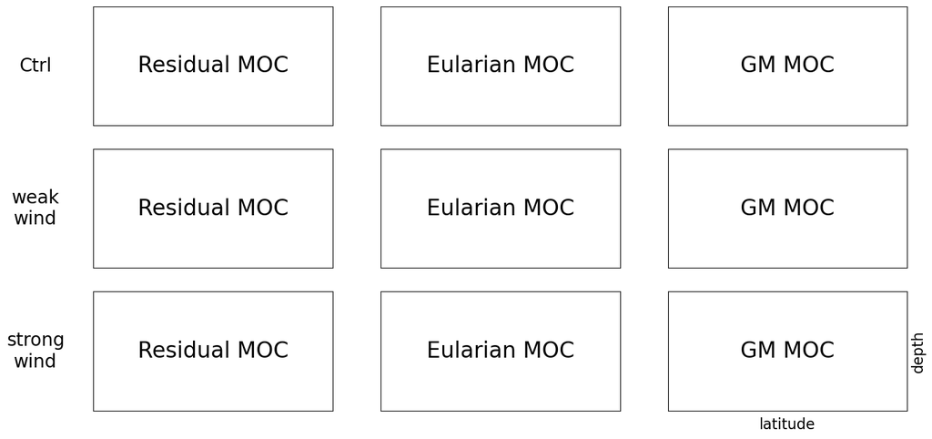

- Eddy component opposes Eulerian mean component (see above in section **Redi/Gent-and-McWilliams-parameterization**)

#### 2. Plot the time mean zonally averaged zonal wind stress maximum versus the maximum of the ACC transport for each simulation

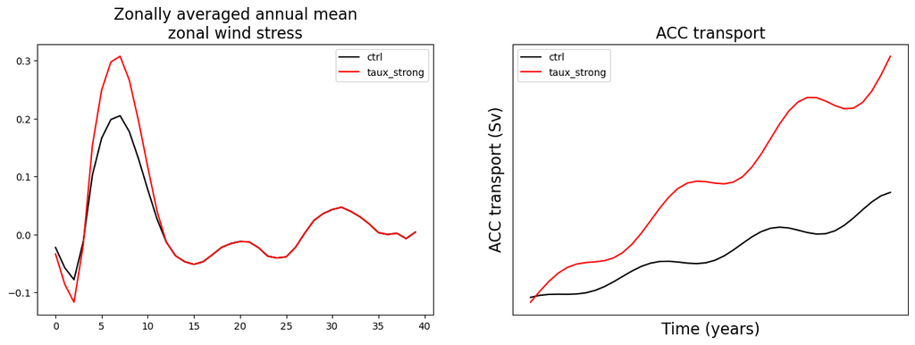

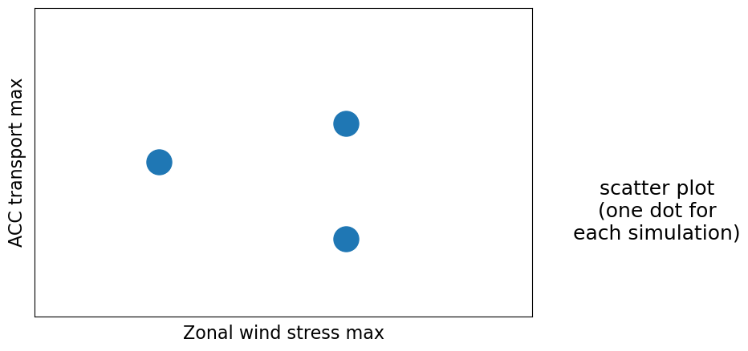

#### 3. Plot of the time mean zonally averaged zonal wind stress maximum versus the maximum of the **upper** cell of the residual MOC

[figure not shown]

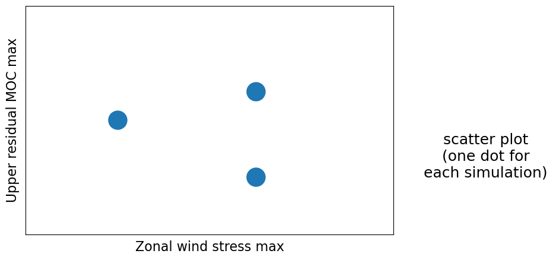

#### 4. Maps of the control, sensitivity and response (i.e. sensitivity minus control) of the winter mixed layer depths

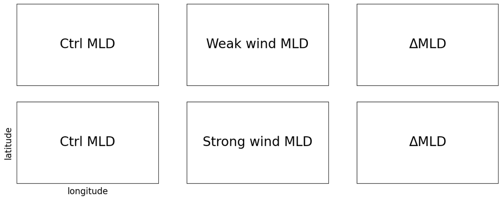

#### 5. Zonal average of the winter mixed layer depth for each simulation

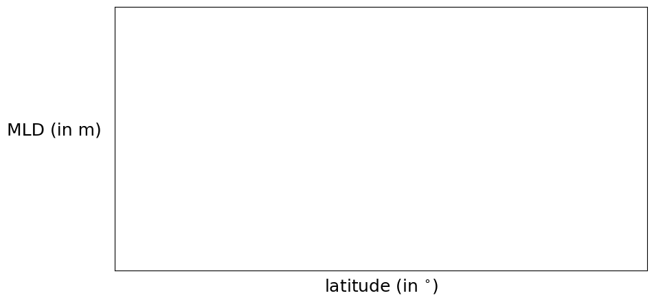

- Zonal average: average along constant latitude (e.g. using the numpy.mean function)

#### 6. Zonally averaged section of the control, sensitivity and response (sensitivity minus control) of the age tracer averaged over the last year

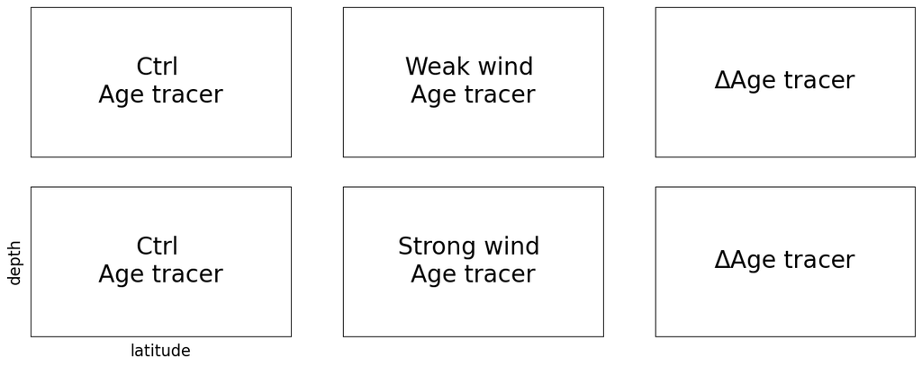

- Zonal average: average along constant latitude (e.g. using the numpy.mean function)
- Age tracer can be found in the `Diag*.nc` files, variable called `TRAC01`

## **Calculation**

### **Mixed Layer depth from T and S**

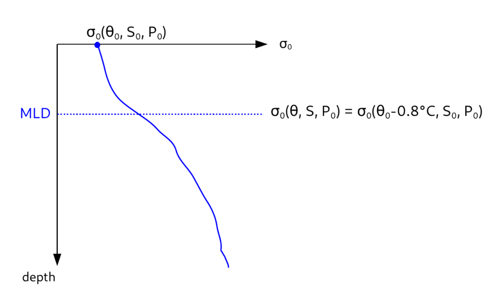

- Compute σ$_{0}$ from temperature and salinity 3D fields: σ(T,S,P=0)
- Compute σ$_{0}$(θ$_{0}$ - 0.8°C, S$_{0}$, P=0) with θ$_{0}$ and S$_{0}$ the surface values
- Find the depth where σ$_{0}$(θ, S, P$_{0}$) - σ0(θ$_{0}$-0.8°C, S$_{0}$, P$_{0}$) is minimized

### **ACC transport**

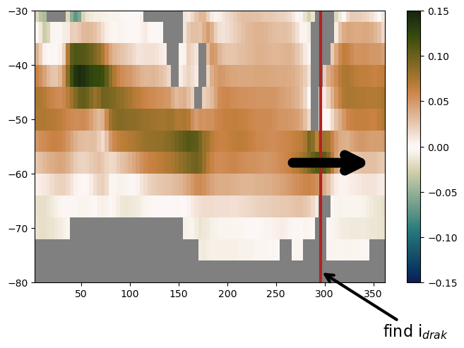

The Antarctic Circumpolar Current transport is evaluated by calculating the mass transport across Drake Passage (Passage between the tip of South America and the tip of the Antarctic Peninsula).

$\mathit{ACCtransport}=\int_{\mathit{bottom}}^{\mathit{surface}}u\, \mathit{hfac} \,dy\,dz$

- Integrate only over the Southern Ocean (30°S-80°S)
- Transport should be in Sv (1 Sv=10$^{6}$ m$^{3}$/s)

### **MOC**

| Residual MOC = | Eulerian mean component | + eddy component |
| --- | --- | --- |
|  | **$\overline{\Psi}$ (Resolved flow)** Given by the velocity output | **$\Psi'$ (Parameterized flow)** Given by the GM parameterization (`gmredi` package) |

**Eddy component**

- Variable `GM_PsiY` found in the `Diag*` files (already a streamfunction)
- Mask the zero values in the `GM_PsiY` variable
- For each year of the simulation, calculate the zonal integral of `GM_PsiY`

$\Psi'=\oint\mathit{GM_{PsiY}}\,dx$

**Eularian mean component**

- Load the meridional velocity component `VVELMASS` in `Diag*` files
- For each year of the simulation, calculate the cumulative vertical sum and zonal integral of `VVELMASS`

$$ \overline{\Psi}(t, y, z) = -\oint \int_{\mathit{bottom}}^{z} \mathit{VVELMASS}(t, y, z')\,\mathit{hfac}\,dz'\,dx $$

| $\mathit{VVELMASS}:$ | 1-year (annual) average |
| --- | --- |
| $\mathit{hfac}:$ | variable `hfacs` |
| $\mathit{dz'}:$ | variable `drF` |
| $\mathit{dx}:$ | variable `dxG` |

- Give both components in Sv
- For the cumulative sum you can use `numpy.cumsum` and for the simple integral `numpy.sum`

## **General comments**

### **Plots**

- Only show the Southern Ocean (30°S-80°S)
- Include labels with units
- Titles for your plots
- Legend and colorbars if that applies
- Large enough fontsize